# Project - Data Mining

## INFERENCE FROM HIERARCHICAL CLUSTERING:

Hence we can predict that the people with more income will accept the personal loan offered to them.

## CLASSIFICATION ALGORITHM:

```r
#Classification Algorithm

setwd("D:/R Progms")
getwd()
```

```
## [1] "D:/R Progms"
```

```r
bdata = readxl::read_xlsx("Thera Bank_Personal_Loan_Modelling-dataset-1 (1).xlsx", sheet = 2)

bdata = na.omit(bdata)

View(bdata)

bdata = bdata[, c(-1,-5)]

bdata$`Family members` = factor(bdata$`Family members`)
bdata$Education = factor(bdata$Education, labels = c("Undergrad", "Graduate", "Advanced/Professional"))
bdata$`Personal Loan` = factor(bdata$`Personal Loan`, labels = c("No", "Yes"))
bdata$`Securities Account` = factor(bdata$`Securities Account`, labels = c("No", "Yes"))
bdata$Online = factor(bdata$Online, labels = c("No", "Yes"))
bdata$CreditCard = factor(bdata$CreditCard, labels = c("No", "Yes"))
bdata$`CD Account` = factor(bdata$`CD Account`,labels = c("No", "Yes")
                            )
library(dplyr)

bdata = bdata %>%
  rename(PersonalLoan = `Personal Loan`,
         Age = `Age (in years)`,
         Experience = `Experience (in years)`,
         IncomePM = `Income (in K/month)`,
         Family = `Family members`,
         SecuritiesAcct = `Securities Account`,
         CDAcct = `CD Account`
         )

View(bdata)
```

```r
library(caTools)
set.seed(2000)
sample = sample.split(bdata,SplitRatio = 0.7)
b_train = subset(bdata,sample == TRUE)
b_test = subset(bdata, sample == FALSE)
View(b_train)

nrow(b_train)
```

```
## [1] 3322
```

```r
nrow(b_test)
```

```
## [1] 1660
```

### The proportion of data is checked if it is the same for both the train and test data

```r
prop.table(table(b_train$PersonalLoan))
```

```
##
##         No        Yes
## 0.90457556 0.09542444
```

```r
prop.table(table(b_test$PersonalLoan))
```

```
##
##         No        Yes
## 0.90301205 0.09698795
```

```r
prop.table(table(bdata$PersonalLoan))
```

```
##
##        No       Yes
## 0.9040546 0.0959454
```

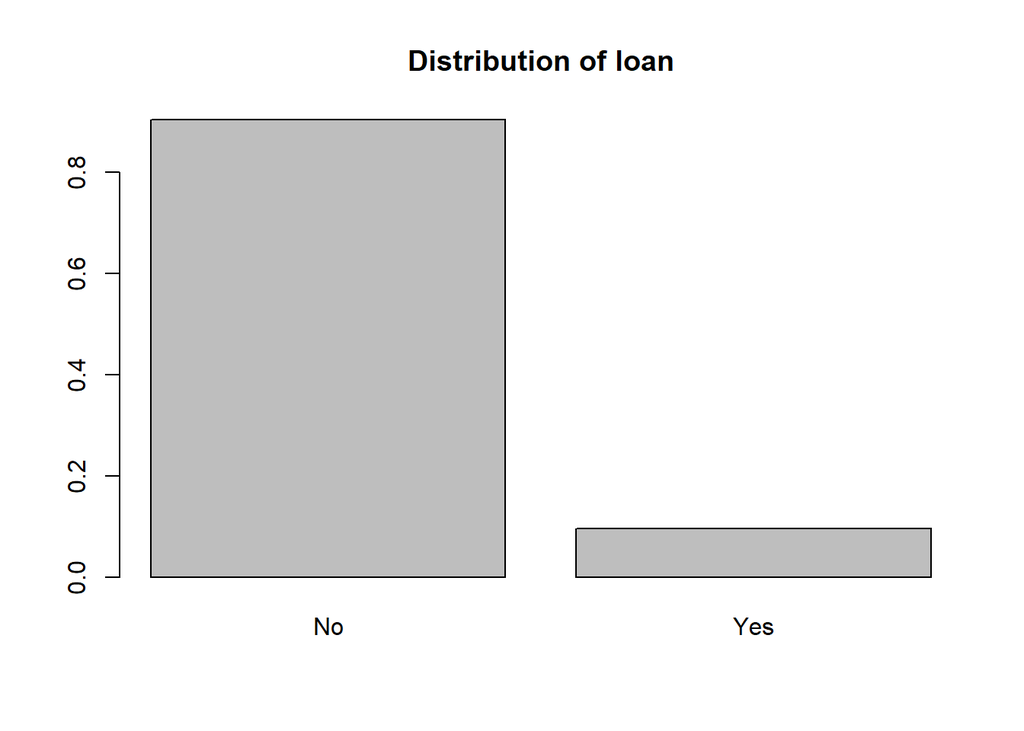

```r
#plotting to visualise

barplot(prop.table(table(bdata$PersonalLoan)),
        main = "Distribution of loan")
```

We find that the data is very unbalanced as, from the data, only 9% of the people have accepted the loan in the last campaign. Hence we will have to balance the imbalanced data to proceed with the classification model in order to avoid any biased result

The data can be balanced by either by oversampling the minority class with replacement and undersampling the majority class without replacement

For this, we use the ROSE (Random Over Sampling Examples) library that helps in generating artificial values for the dataset.

```r
library(ROSE)
bdata.balcd = ROSE(formula = PersonalLoan ~ Age+Experience+IncomePM+Family +CCAvg+Education+Mortgage+SecuritiesAcct+CDAcct+Online+CreditCard , data = b_train, p = 0.5, seed = 1)$data

table(bdata.balcd$PersonalLoan)
```

```
##
##   No  Yes
## 1713 1609
```

```r
prop.table(table(bdata.balcd$PersonalLoan))
```

```
##
##        No       Yes
## 0.5156532 0.4843468
```

```r
library(caTools)
set.seed(2000)
sample = sample.split(bdata.balcd,SplitRatio = 0.7)
b_train = subset(bdata.balcd,sample == TRUE)
b_test = subset(bdata.balcd, sample == FALSE)

prop.table(table(b_train$PersonalLoan))
```

```
##
##        No       Yes
## 0.5153568 0.4846432
```

```r
prop.table(table(b_test$PersonalLoan))
```

```
##
##        No       Yes
## 0.5162455 0.4837545
```

```r
prop.table(table(bdata.balcd$PersonalLoan))
```

```
##
##        No       Yes
## 0.5156532 0.4843468
```

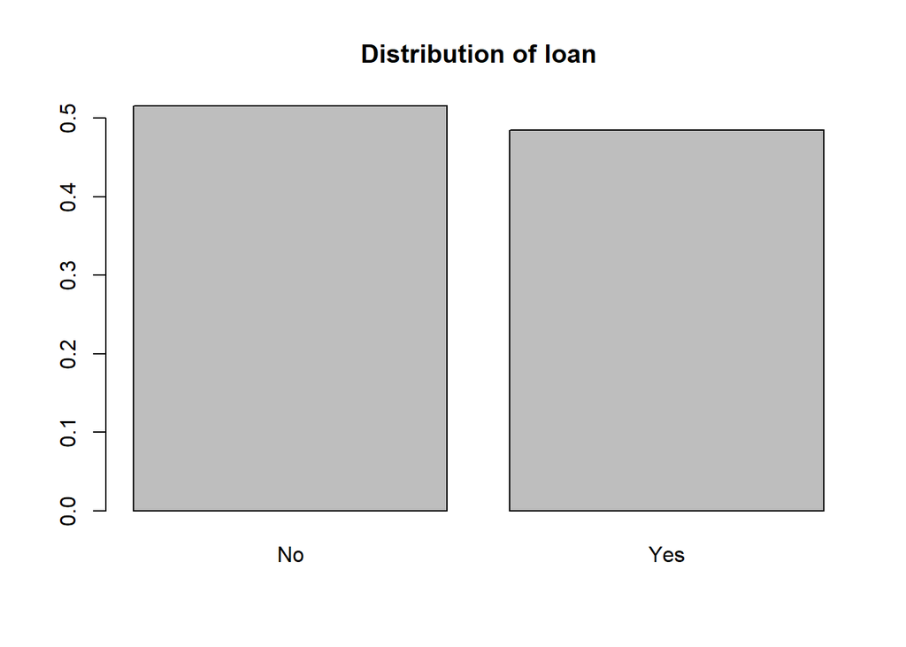

```r
barplot(prop.table(table(bdata.balcd$PersonalLoan)),
        main = "Distribution of loan")
```